# Rongkui_Chap14.7

Rongkui Han

7/6/2020

You want to rest the hypothesis that the range size of carnivores is influenced by their body size (larger carnivores roam further). You want to be sure that if you do see a relationship that is is not just due to shared evolutionary history. That is you want to do a phylogenetic regression.

1. Load the data as follows:

```r
library(rethinking)
library(ape)
library(ade4)
library(dplyr)
library(tidyverse)
data("carni70")
```

```r
tre = read.tree(text=carni70$tre)
d = carni70$tab
```

2. Note that the species name given in “rownames(d)” and in “tre$tip.label” do not match. Fix that (e.g. using `str_replace()`)

```r
tre$tip.label = str_replace(tre$tip.label, "\\.", "_")
```

3. Should either range or size be transformed?

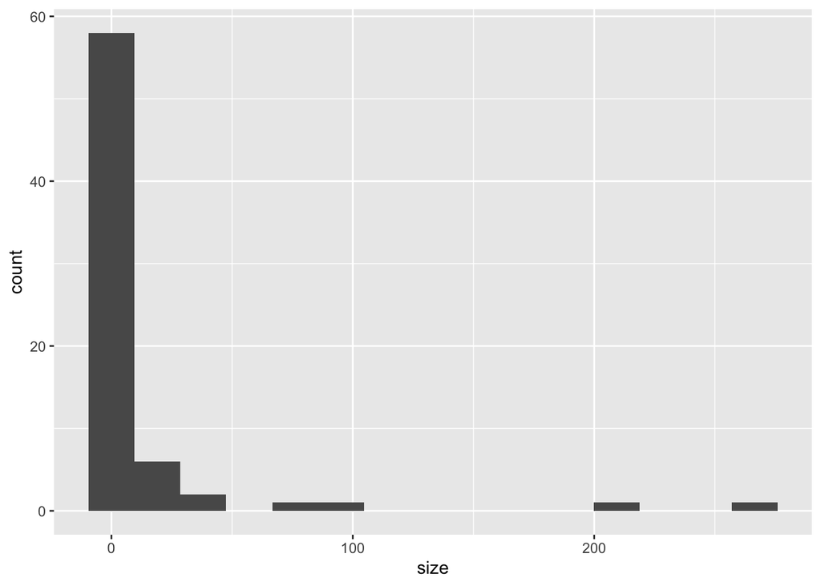

```r
ggplot(d, aes(x = size)) +
  geom_histogram(bins = 15)
```

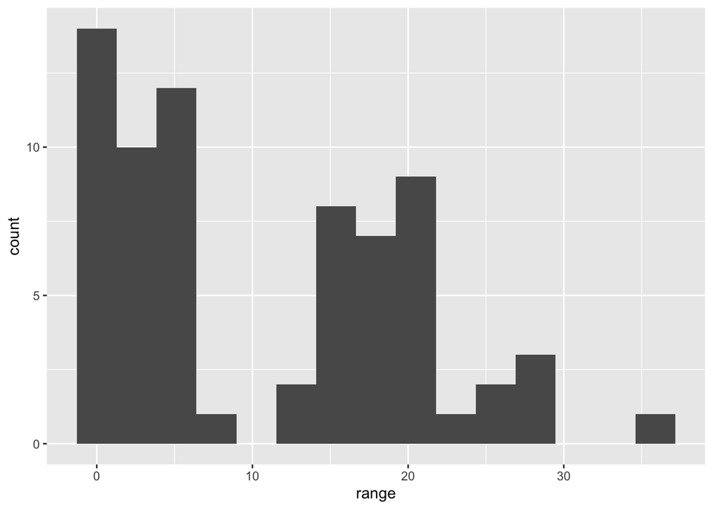

```r
ggplot(d, aes(x = range)) +
  geom_histogram(bins = 15)
```

```r
d['log_size'] = log(d$size)
d['scaled_range'] = range(d$range)
```

4. Does size predict range? Evaluate this question without and with accounting for phylogenetic relationships.

Without phylogenetic relationships:

```r
dat_list <- list(
  N_spp = nrow(d),
  R = d$scaled_range,
  S = d$log_size,
  Imat = diag( nrow(d) )
)
mod_noPhy <- ulam(
  alist(
    R ~ multi_normal( mu , SIGMA ),
    mu <- a + bS*S ,
    matrix[N_spp,N_spp]: SIGMA <- Imat * sigma_sq,
    a ~ normal( 0 , 1 ),
    bS ~ normal( 0 , 0.5 ),
    sigma_sq ~ exponential( 1 )
  ), data=dat_list , chains=4 , cores=4)
```

```
## Trying to compile a simple C file
```

[output not shown]

```r
precis( mod_noPhy )
```

```
##                mean        sd       5.5%      94.5%    n_eff      Rhat
## a          6.485837 0.8537984  5.1060141   7.875421 1456.149 1.0001615
## bS         1.417813 0.4075258  0.7492379   2.062782 1592.474 1.0009540
## sigma_sq 106.172262 7.1037933 95.0783243 117.773643 1470.891 0.9995802
```

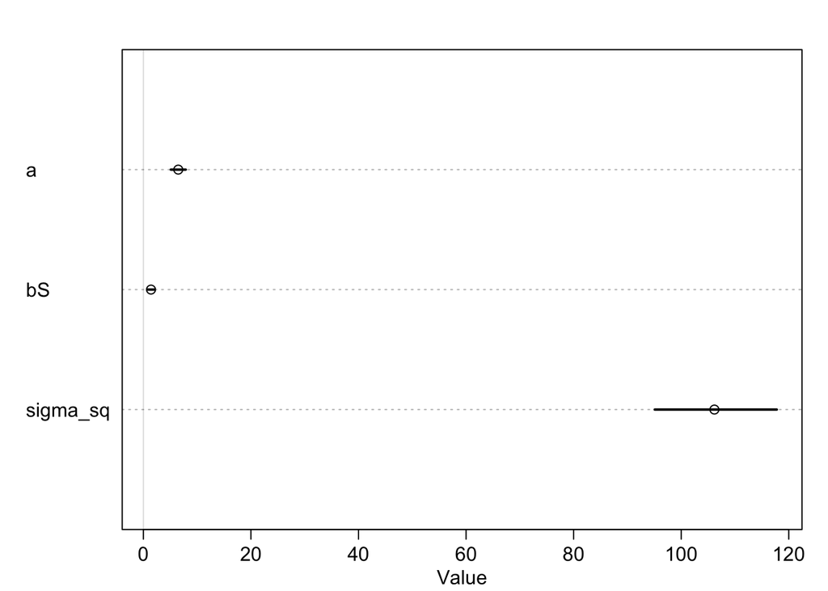

```r
plot(precis(mod_noPhy))
```

> There is a small but significant positive correlation between size and range.

With phylogenetic relatshipship, linear method:

```r
tree_trimmed <- keep.tip( tre, rownames(d) )
Dmat <- cophenetic( tree_trimmed )
spp_obs = rownames(d)
N_spp = nrow(d)

Rbm <- corBrownian( phy=tree_trimmed )
V <- vcv(Rbm)

dat_list$V <- V[ spp_obs , spp_obs ]
# convert to correlation matrix
dat_list$rel <- dat_list$V / max(V)

mod_Phy <- ulam(
  alist(
    R ~ multi_normal( mu , SIGMA ),
    mu <- a + bS*S,
    matrix[N_spp,N_spp]: SIGMA <- rel * sigma_sq,
    a ~ normal( 0 , 1 ),
    bS ~ normal( 0 , 0.5 ),
    sigma_sq ~ exponential( 1 )
  ), data=dat_list , chains=4 , cores=4 )
```

```
## Trying to compile a simple C file
```

[output not shown]

```r
precis( mod_Phy, depth = 3)
```

```
##                 mean         sd        5.5%      94.5%    n_eff     Rhat
## a          0.1006396  0.9974171  -1.4946080   1.651996 1976.163 1.000193
## bS         1.2765543  0.4613922   0.5392641   2.025788 1899.202 1.001246
## sigma_sq 562.8563050 15.9957616 537.8644617 588.781805 1725.669 1.000590
```

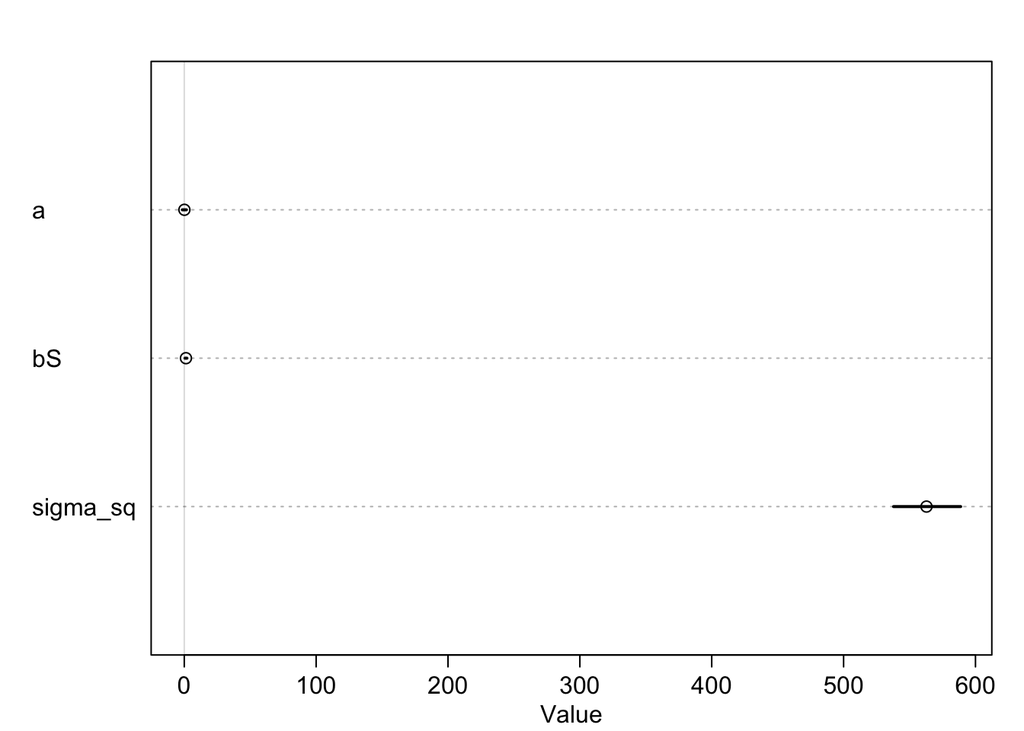

```r
plot(precis( mod_Phy, depth = 3))
```

> Size effect sill present. The estimated value of bS is similar to that of the phylogenetic-blind model. Sigma_sq got really large for some reason…

With phylogenetic relationships, OU method:

```r
dat_list$Dmat <- Dmat[ spp_obs , spp_obs ] / max(Dmat)

mod_OU <- ulam(
  alist(
    R ~ multi_normal( mu , SIGMA ),
    mu <- a + bS*S ,
    matrix[N_spp,N_spp]: SIGMA <- cov_GPL1( Dmat , etasq , rhosq , 0.01 ),
    a ~ normal(0,1),
    bS ~ normal(0,0.5),
    etasq ~ half_normal(1,0.25),
    rhosq ~ half_normal(3,0.25)
  ), data=dat_list , chains=4 , cores=4)
```

```
## Trying to compile a simple C file
```

[output not shown]

```r
precis( mod_OU, depth = 3)
```

```
##            mean        sd      5.5%     94.5%    n_eff      Rhat
## a     10.617543 0.5955676  9.649296 11.577523 1498.158 0.9994000
## bS     2.426985 0.2454263  2.040640  2.818377 1651.366 0.9987114
## etasq 13.085530 0.1542709 12.843321 13.330329 2227.790 0.9989979
## rhosq 12.489260 0.1587015 12.228876 12.739491 2468.887 0.9994437
```

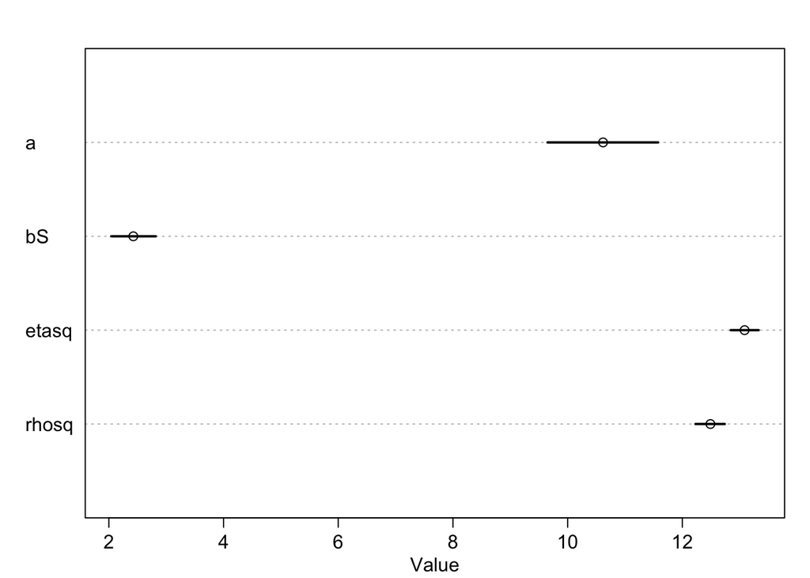

```r
plot(precis( mod_OU ))
```

5. Discuss your findings.

> Curiously, the phylogenetic OU model predicts stronger correlations between size and range.